# Problem Set 8 - Andrew Koren

## Problem 1

a) solenoids compactly focus in both $x'$ and $y'$ so long as the right length vs edge kick parameters are met, although they require columnated input (straight on-axis beam) to prevent errors. They are used in sources where straight beams are easy to achieve and as small corrections when full quadrupoles are difficult to fit. Quadrupoles can only focus in one plane and defocus in the other, but can have net focusing in FODO cell arrangements. They do not care about incoming beam transverse motion, especially in the thin-lens approximation. Both can have varying focusing effects based on momentum variation of input beams (chromaticity).

b) Is this a reference to pset 4? Both magent types have weak focusing in the horizontal plane, where there cannot be a phase advance greater than $\Delta \phi = 2\pi$ (hence weak). Ideal sector bend dipoles have magnetic field faces perpendicular to the beam and thus have no edge focusing, but rectangular magnets have vertical edge focusing similar to a quadrupole (defocusing in horizontal).

## Problem 2

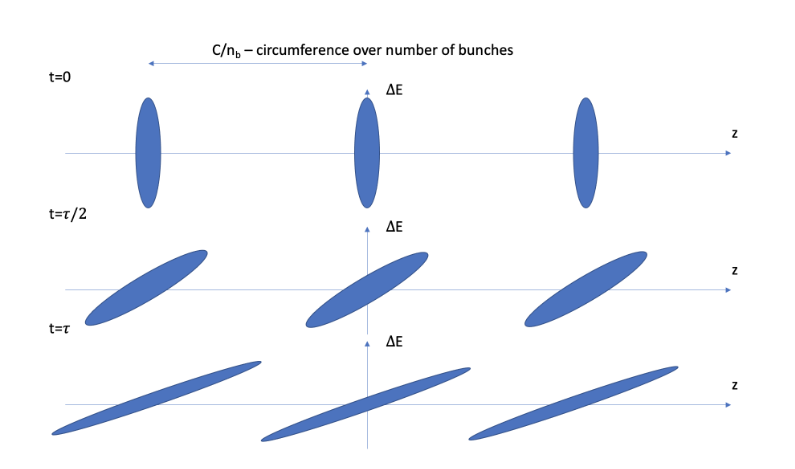

## Problem 3

a) The invariant occurs when there is no beam "heating" or "cooling" - emmittance is constant. This occurs when there is no lossy resistance or energy dumped into the beam, and the Courant-Synder Invariant in particular comes from the lorentz requirement that no work is done (bending magnets, quads, etc).

b)

- emittance: varienty of meanings but often relating to some enclosed space with a fixed courant snyder invariant
- rms emittance: area around the center of the beam (shape set by twiss parameters) that encloses some mean number of particles (often $\sigma,\ 2\sigma,\ 3\sigma$ from normal distribution )
- normalized emittance scales with energy growth so it isn't affected by invariant value changes

## Problem 4

The distance of the wires to $(0,0,z)$ must scale with $a$. We will make them in the $\hat z$ direction and cancel out the $\hat x$ component of the magnetic field with symmetry. Let's place one wire at $c \hat x$ and two wires at $b \hat x \pm b \hat y$

$$ \begin{gathered} \hat B = \pm' \hat z \times \hat r_{\text{sep}} \\ \begin{gathered} |B_c| = {\mu_0 I_0 \over 2 \pi c} & |B_b| = {\mu_0 I_0 \over 2\sqrt{2} \pi b} \\ \hat r_{\text{sep},b} = - \hat x & \hat r_{\text{sep},c} = {\hat x \mp \hat y \over \sqrt 2} \\ \hat B_c= \mp' \hat y & \hat B_{b\pm}= {\pm' \hat y \pm'\pm \hat x \over \sqrt 2} \end{gathered} \end{gathered} $$

We can control the $\pm'$ for each wire individually, but cancelling the $\hat x$ component of the two $\vec B_b$ wires requires alignment. This yields

$$ \begin{gathered} \vec B_{b-} + \vec B_{b+} = \pm' {\mu_0 I_0 \over 2 \pi b} \hat y \\ \vec B_c = \mp' {\mu_0 I_0 \over 2\pi c} \hat y \\ B_y = \pm^{(1)}{\mu_0 I_0 \over 2 \pi b} \mp^{(2)} {\mu_0 I_0 \over 2\pi c} % = {3 \mu_0 I_0 \over \pi a} \end{gathered} $$ where each $\pm^{(i)}$ depends on whether current flows in the $\pm \hat z$ direction

There are infiniely many solutions for any given $a$, which makes sense considering this could also be done with just a single wire. If all wires are in the $+\hat z$ direction:

$$ \begin{gathered} B_y = {\mu_0 I_0 \over 2 \pi b} - {\mu_0 I_0 \over 2\pi c} = {3 \mu_0 I_0 \over \pi a} \\ a = 6b -6c \end{gathered} $$

## Problem 5

a) based on the $1\over \rho$ power scaling in Wiedmann 24.34 we need to increase radius by $\sqrt{10}$

b) rescale by $\gamma/e$ parameters: ${r_c m \over r_c m} = 0.983$, but $\gamma$ will also change

$$ \begin{gathered} {\gamma_e} = {100\times 10^6 \over 511} = 195694 \\ {\gamma_\mu} = {100\times 10^3 \over 105} = 952 \\ {\beta^3 \gamma^4 \over \beta^3 \gamma^4} = 5.6\times 10^{-10} \end{gathered} $$

now we just need to get the muons to that energy

```python
gamma_e = 100e6/511
gamma_mu = 100e3/105

beta_e = (1-(1/gamma_e)**2)**(1/2)
beta_mu = (1-(1/gamma_mu)**2)**(1/2)

(gamma_mu**4*beta_mu)/(gamma_e**4*beta_e**3)
```

[output not shown]